# Contour Plots

## Introduction

The intention of this vignette is to show how to plot different styles of contour plot using the BCEA package and the `contour()` and `contour2()` functions.

#### R code

To calculate these in BCEA we use the `bcea()` function.

```r
data("Vaccine")
he <- bcea(eff, cost, ref = 2)
```

The plot defaults to base R plotting. Type of plot can be set explicitly using the `graph` argument.

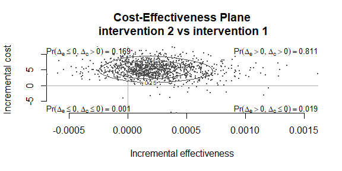

```r
contour(he, graph = "base")
```

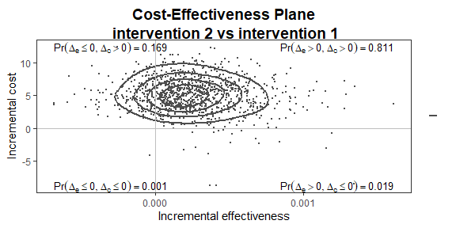

```r
contour(he, graph = "ggplot2")
```

```r
# ceac.plot(he, graph = "plotly")
```

User-defined contour levels can be provided. The `levels` and `nlevels` arguments specify the quantiles or number of levels. The base R levels arguments are kept for back-compatibility and the `ggplot2` style arguments are used in the associated plot.

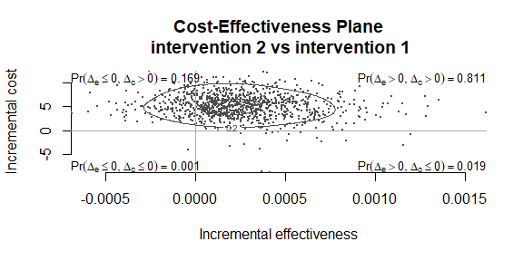

```r
contour(he, levels = c(0.2, 0.8))
```

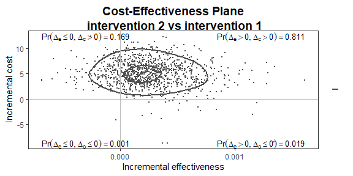

```r
contour(he, graph = "ggplot2", contour = list(breaks = c(0.2, 0.8)))
```

Other plotting arguments can be specified such as title, line colour and thickness and type of point.

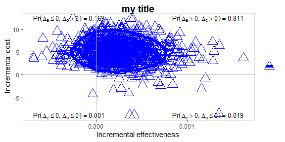

```r
contour(he,
        graph = "ggplot2",
        title = "my title",
        point = list(color = "blue", shape = 2, size = 5),
        contour = list(size = 2))
```

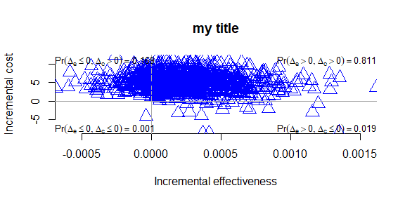

```r
contour(he,
        graph = "base",
        title = "my title",
        point = list(color = "blue", shape = 2, size = 2),
        contour = list(size = 2))
```

Alternatively, the `contour2()` function is essentially a wrapper for `ceplane.plot()` with the addition of contour lines.

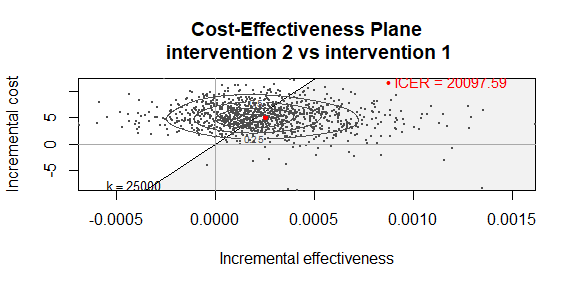

```r
contour2(he, graph = "base")
```

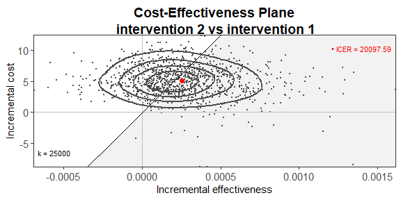

```r
contour2(he, graph = "ggplot2")
```

```r
# ceac.plot(he, graph = "plotly")
```

Other plotting arguments can be specified in exactly the same way as above.

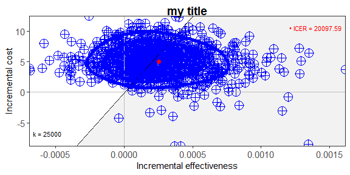

```r
contour2(he,
         graph = "ggplot2",
         title = "my title",
         point = list(color = "blue", shape = 10, size = 5),
         contour = list(size = 2))
```

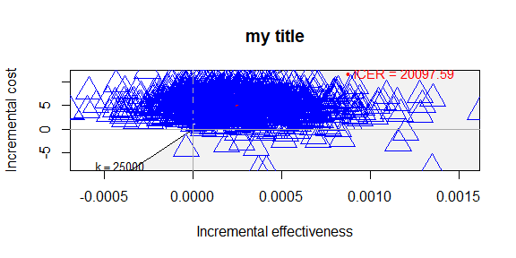

```r
contour2(he,
         graph = "base",
         title = "my title",
         point = list(color = "blue", shape = 2, size = 3),
         contour = list(size = 4))
```

## Multiple interventions

This situation is when there are more than two interventions to consider.

#### R code

```r
data("Smoking")
he <- bcea(eff, cost, ref = 4)
# str(he)
```

Because there are multiple groups then the quadrant annotation is omitted.

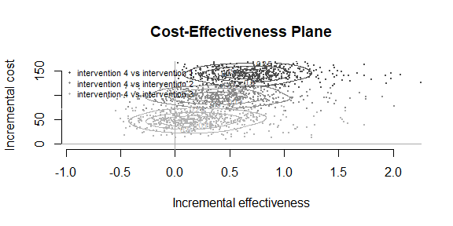

```r
contour(he)
```

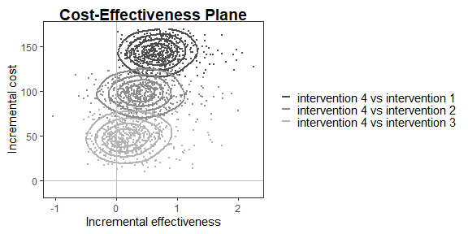

```r
contour(he, graph = "ggplot2")
```

The `scale` argument determines the smoothness of the contours.

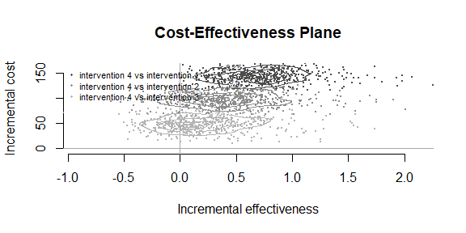

```r
contour(he, scale = 0.9)
```

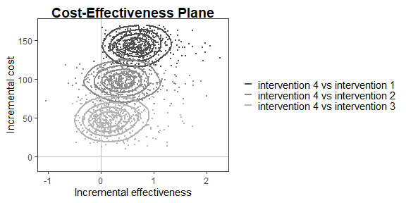

```r
contour(he, graph = "ggplot2", scale = 0.9)  ##TODO: what is the equivalent ggplot2 argument?
```

The quantiles or number of levels.

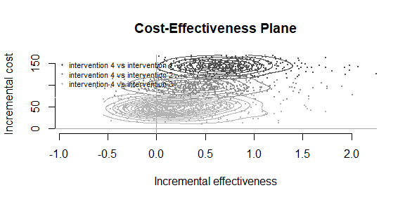

```r
contour(he, nlevels = 10)
```

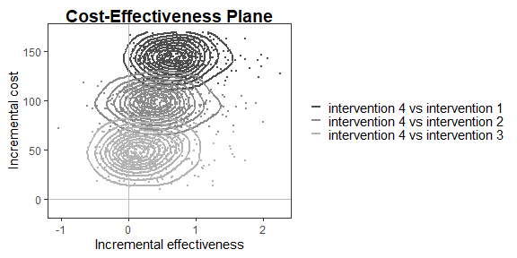

```r
contour(he, graph = "ggplot2", contour = list(bins = 10))
```

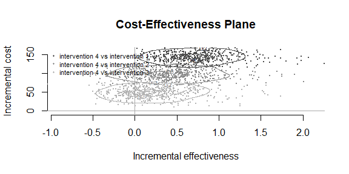

```r
contour(he, levels = c(0.2, 0.8))
```

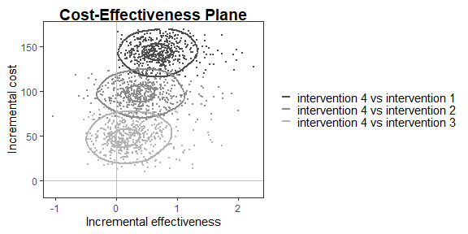

```r
contour(he, graph = "ggplot2", contour = list(breaks = c(0.2, 0.8)))
```

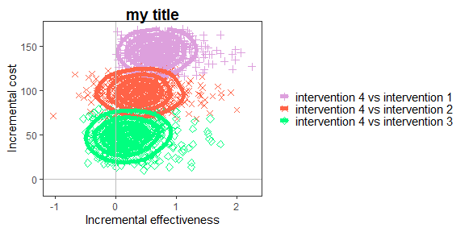

```r
contour(he,
        graph = "ggplot2",
        title = "my title",
        line = list(color = "red", size = 1),
        point = list(color = c("plum", "tomato", "springgreen"), shape = 3:5, size = 2),
        icer = list(color = c("red", "orange", "black"), size = 5),
        contour = list(size = 2))
```

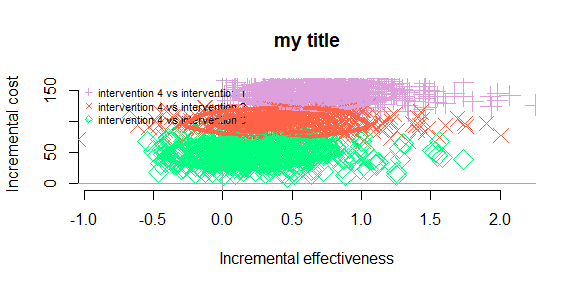

```r
contour(he,
        graph = "base",
        title = "my title",
        line = list(color = "red", size = 1),
        point = list(color = c("plum", "tomato", "springgreen"), shape = 3:5, size = 2),
        icer = list(color = c("red", "orange", "black"), size = 5),
        contour = list(size = 4))
```

Again, this applies to the `contour2()` version of contour plot too.

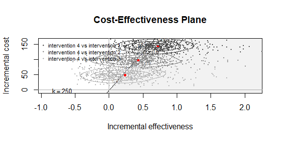

```r
contour2(he, wtp = 250)
```

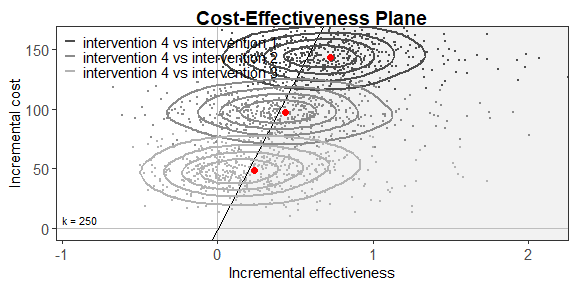

```r
contour2(he, wtp = 250, graph = "ggplot2")
```

The styling of the plot for multiple comparisons can specifically change the colour and point type for each comparison.

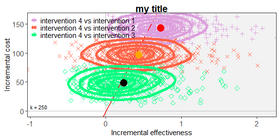

```r
contour2(he, wtp = 250,
         graph = "ggplot2",
         title = "my title",
         line = list(color = "red", size = 1),
         point = list(color = c("plum", "tomato", "springgreen"), shape = 3:5, size = 2),
         icer = list(color = c("red", "orange", "black"), size = 5),
         contour = list(size = 2))
```

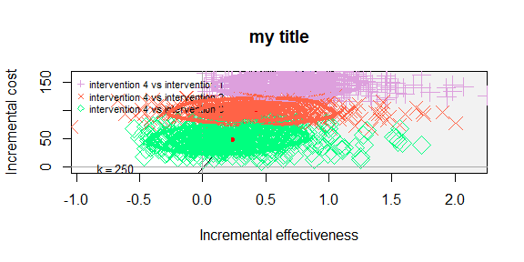

```r
contour2(he, wtp = 250,
         graph = "base",
         title = "my title",
         line = list(color = "red", size = 1),
         point = list(color = c("plum", "tomato", "springgreen"), shape = 3:5, size = 2),
         icer = list(color = c("red", "orange", "black"), size = 5),
         contour = list(size = 4))
```

Reposition legend.

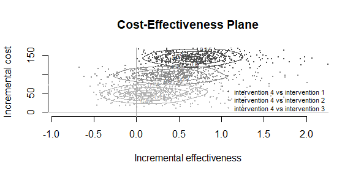

```r
contour(he, pos = FALSE)    # bottom right
```

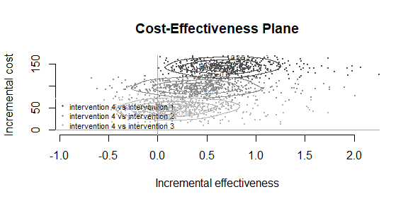

```r
contour(he, pos = c(0, 0))
```

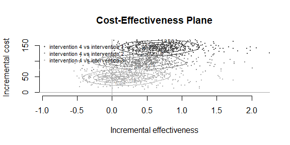

```r
contour(he, pos = c(0, 1))
```

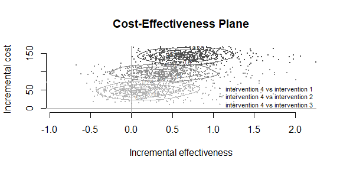

```r
contour(he, pos = c(1, 0))
```

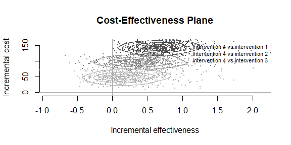

```r
contour(he, pos = c(1, 1))
```